# Charlie Munger Hates Windows: An Analysis

Seeing the effects of windows on one’s well-being.

Wylie Hampson

2021-11-28

## Introduction

This last summer I began a new journey in pursuing my Masters of Environmental Data Science at the Bren School of Environmental Science and Management at the University of California in Santa Barbara. My experience has been nothing short of wonderful so far, but unfortunately for many of the other students at UCSB that has not been the case. I started my school year in the middle of the summer while many of the other students were away, so finding an apartment to live in on campus was easy. As the summer was coming to an end though and students were coming back to campus, it quickly became evident that there were more students than UCSB could house. Oops! Now I’m not here to point fingers and blame anyone, but this was definitely a huge mistake that caused many problems. UCSB tried to combat the issue by putting some students in hotel rooms, but some students even had to resort to living in their cars for the start of Fall Quarter 2021. In an attempt to solve this issue, UCSB decided to build a new mega dormitory for students to live in. The proposed dormitory would be a 1.5 billion dollar project, so UCSB started taking donations. One donor was particularly interested in the new dorm. A billionaire by the name of Charlie Munger. Charlie Munger is the vice chairman of Berkshire Hathaway, one of Warren Buffet’s right hand men, and has had previous ties with UCSB. He promised UCSB a 200 million dollar donation on the condition that he could make many of the architectural decisions on the dorm. Sure why not, what’s the worst that could happen? Well… Charlie decided he wanted to build the dorm so that 94% of the rooms didn’t have windows. According to this [article from the LA Times](https://www.latimes.com/opinion/story/2021-11-02/editorial-donors-should-give-to-universities-with-no-strings) , Charlie feels as though students can happily live in windowless bedrooms and do just fine. Now maybe I’m in the minority here, but to me, depriving students of natural light and views, especially in a beautiful place like Santa Barbara, feels a bit… evil. But I’m here studying data science! So before I make any large assumptions about Mr. Munger, I figured I’d first see what the data has to say.

## My Data

So does students having a window in their bedroom really have an effect on their well-being? I figured that there were multiple ways of answering this question. I wanted to find a dataset that would either look at students grades or peoples’ mental/physical health when compared to either their exposure to natural light, or whether or not they have windows in their bedrooms. What I found was [a dataset](https://figshare.com/articles/dataset/Data_for_the_paper_A_room_with_a_view_the_importance_of_nearby_nature_for_mental_health_during_the_COVID-19_pandemic_/12941729/1) that was taken from Tokyo, Japan in 2020. This dataset was collected to look at how people were being affected by the Covid-19 pandemic by having to spend more time indoors. A survey was collected from 3000 Japanese citizens that asked them questions about their self-esteem, life satisfaction, subjective happiness, depression and anxiety, and loneliness. The participants ranked these questions, which gave them a score for each category. Then the participants were asked questions about how often they go to outdoor green spaces in their area, and whether or not they have a window with a view of nature from the room that they spend most of their time in. Note that this doesn’t mean whether they do or do not have a window in that room, just whether or not there is a view of nature from that window. Here nature is described as something as simple as even a tree on the side of a street. More information on this dataset can be found [here](https://esajournals.onlinelibrary.wiley.com/doi/full/10.1002/eap.2248). This data isn’t perfectly ideal for answering the question I’m looking at, but it rarely is unless I were to collect the data myself, and this data should be able to give us a really good idea about how having windows can affect ones well being.

## My analysis

To start my analysis I decided to filter out the data so that I was only looking at people age 30 and younger. My main reasoning for doing this is because I’m mostly focused on how windows will effect the people that will be living in UCSB’s new dorm, which I assume will primarily be people below the age of 30.

```r
data <- data %>%
  filter(age <= 30)
```

Next, instead of looking at each mental health ranking individually I decided to combine them all together to get one overall well-being score to look at. To do this I added up all of the positive well-being traits which were the scores for life satisfaction, self-esteem, and subjective happiness, then I subtracted all of the negative well-being scores, which were depression and anxiety, and loneliness. This gave me an overall well-being score for each participant.

```r
data <- data %>%
  mutate(well_being = (life_satisfaction + self_esteem + subjective_happiness) -
           (depression_and_anxiety + loneliness))
```

### First question: How does having a view of nature affect well-being?

I first wanted to know if the mean well-being score of someone who did not have a view of nature had a statistically significant difference from someone who did have a view of nature. So I grouped my data into two groups, those who had a view of nature and those who did not, and then I created a quick box plot just to see what the data distribution looks like between the two groups.

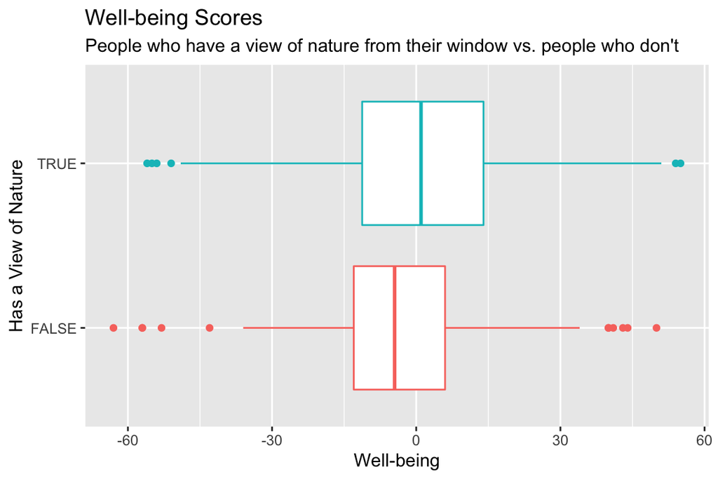

By looking at the box plot above we can see that the group of people that do have a view of nature from their bedroom seem to have higher well-being scores on average. But are they statistically significant? In order to find that out I ran a t-test:

```r
t.test(well_being ~ nature_view, data = data)
```

```
##
##  Welch Two Sample t-test
##
## data:  well_being by nature_view
## t = -2.0594, df = 267.27, p-value = 0.04043
## alternative hypothesis: true difference in means between group FALSE and group TRUE is not equal to 0
## 95 percent confidence interval:
##  -7.7382736 -0.1738615
## sample estimates:
## mean in group FALSE  mean in group TRUE
##           -2.890411            1.065657
```

From the above results we can see that we end up with a p-value of 0.04043. This means that at a significance level of 0.05 we **can** reject the null hypothesis that there is no significant difference between the mean well-being scores of people who have a view of nature from their bedroom and people who do not, and we **can** say that there is a significant difference at the 5% level!

### Second question: What if students just went outside more?

So after looking at the last question I began to wonder: “What if students just went outside more often? Would it really matter if they didn’t have a window with a nature view in their bedroom?” Luckily, the dataset that I’m working with also had data on how frequently each participant had visited their nearest green space in the previous month. So I created a parallel slopes model using ordinary least squares (OLS):

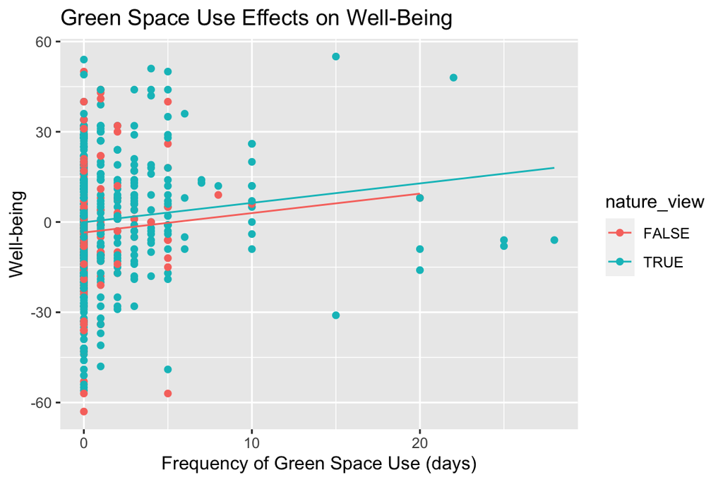

And here we can see the summary and coefficients of the above model, as well as the $R^2$ value:

|  | Estimate | Std. Error | t value | Pr(>\|t\|) |
| --- | --- | --- | --- | --- |
| (Intercept) | -3.4969214 | 1.678282 | -2.083632 | 0.0376642 |
| greenspace_use_frequency | 0.6463542 | 0.254572 | 2.538984 | 0.0113975 |
| nature_viewTRUE | 3.4020784 | 1.955656 | 1.739610 | 0.0824984 |

```
## [1] "R-squared value = 0.0192690554741357"
```

In the above plot we can see that first of all there does seem to be an increase in well-being score as the frequency of green space use increases on average. Second, we can see that there still seems to be higher well-being scores on average overall for people who do have a window with a view of nature from their bedroom. If we look at the summary we can see the different coefficients. The intercept coefficient is saying that for people who spent 0 days at a green space, and did not have a window with a view of nature, on average they would be expected to have a well-being score of -3.4969. The greenspace_use_frequency coefficient is the slope of the two lines, so it’s saying that on average, for every one day increase that a person spent using a green space, their well-being is expected to increase by 0.6464 points. Finally, the nature_viewTRUE coefficient is saying that people that have a view of nature out of their bedroom window are expected to have a higher well-being score by 3.4021 on average than people who use green spaces with the same frequency, but don’t have a view of nature out of their bedroom window. **However!** There are a few things to take into consideration with this model. First of all, notice how this model has a pretty low R-squared value of 0.019. This means that there is not a strong relationship between the frequency of green space use and well-being. A person’s well-being is obviously affected by so many different things that you cannot simply attribute it all to how often a person visits a green space. Because of that, there is almost certainly omitted variable bias here, meaning that there are other variables that affect well-being that I have not included in my model. And finally, the variance appears to change along the x-axis, meaning there appears to be heteroscedasticity which would make OLS not the most accurate model. This is largely caused by a lack of data for people that used green spaces at higher frequencies. However, I also plotted the same model using all of the survey participants instead of just the people under 30 to see what it would look like, and the variance along the x-axis appears much more homoscedastic.

## Some limitations

Before I make any major conclusions on my original question I think that it’s important to first recap some of the limitations in my analysis. The main limitations to my question come from the data that I used. I was interested in looking at how having a bedroom window affects students compared to not having a bedroom window. The data that I looked at looks at people age 20 and up, and I just decided to look at the people 30 and under, but that doesn’t mean they are students. The data that I looked at also was looking at having a view of nature, not necessarily whether or not a person has any kind of window, although not having a window would also mean you don’t have a view of nature. This data was also recorded in Tokyo, so maybe the results would be different if they were taken from a rural area instead of a metropolitan area. And finally, this data was taken during a global pandemic where peoples’ mental health and well-being will almost certainly be different than under normal circumstances.

## Conclusion

So after all of my analyses, and after reviewing all of the different limitations, can we say for sure that having bedroom windows improves students well-being? In short, I would say that no, we can’t make any absolute conclusions like that. **However**, seeing that having a window with a view of nature had a statistically significant improvement on young peoples lives, during a global pandemic, is enough for me to hold onto my opinion that windows do make a difference in improving peoples mental health. In my opinion after doing this analysis, by making rooms without windows for students at UCSB, the school is just taking away from the students’ college experience and making their lives worse than they need to be, all to save a little bit of money (I assume that’s why they aren’t installing windows instead of some kind of twisted experiment). So my final thoughts are that A. I don’t know why Charlie Munger feels so strongly about treating the UCSB student body this way, and B. I don’t know why UCSB is giving Charlie Munger so much power over the dormitory plans when he’s only funding about 13% of it. But either way I think there needs to be windows in **all** of the dormitory bedrooms. I would love to hear other peoples thoughts!

Thanks for reading!

[Here is a link for my github repo where I wrote my code.](https://github.com/wyliehampson/EDS222_final_proj)

## References:

- Soga, Masashi, Maldwyn J. Evans, Kazuaki Tsuchiya, and Yuya Fukano. “A Room with a Green View: The Importance of Nearby Nature for Mental Health during the COVID-19 Pandemic.” Ecological Applications 31, no. 2 (2021): e2248. https://doi.org/10.1002/eap.2248.
- LA Times Editorial Board. “Editorial: Donors Should Give to Universities with No Strings, Not Dictate Their Look or Academics.” Los Angeles Times, November 2, 2021. https://www.latimes.com/opinion/story/2021-11-02/editorial-donors-should-give-to-universities-with-no-strings.